# Advanced plotting

Jeff Powell and Remko Duursma

31 March 2017

# Introduction

Here, our focus is on advanced topics, particularly (i) interacting with the graphics window to produce more complicated plot types and (ii) examples of useful plot types that can be produced with specific packages.

## base or ggplot2?

In this document we focus on using the base graphics system, but also show a few examples with the popular `ggplot2` package. The advantage of `ggplot2` is that complex graphs, containing multiple panels, grouping variables, and so on, can be constructed with very little code. The disadvantage is that if the user wishes to modify any (or all) aspect of the plot, it becomes more and more difficult. The disadvantage of the base graphics system is that we often have to write quite a lot of code to construct more complicated plots, but the advantage is that modifying layout, annotations, etc. is much more straightforward. Many R packages also provide plotting functions for the base graphics system, thus providing many options.

# External legend

Legends are easy to produce, but it can be difficult to find space for the legend on some plots, especially if there is a lot of text in the legend. However, we can use the ‘xpd’ argument in the ‘par’ function to set up a plot that allows us to prepare a legend on the outside of the plot margins. For example,

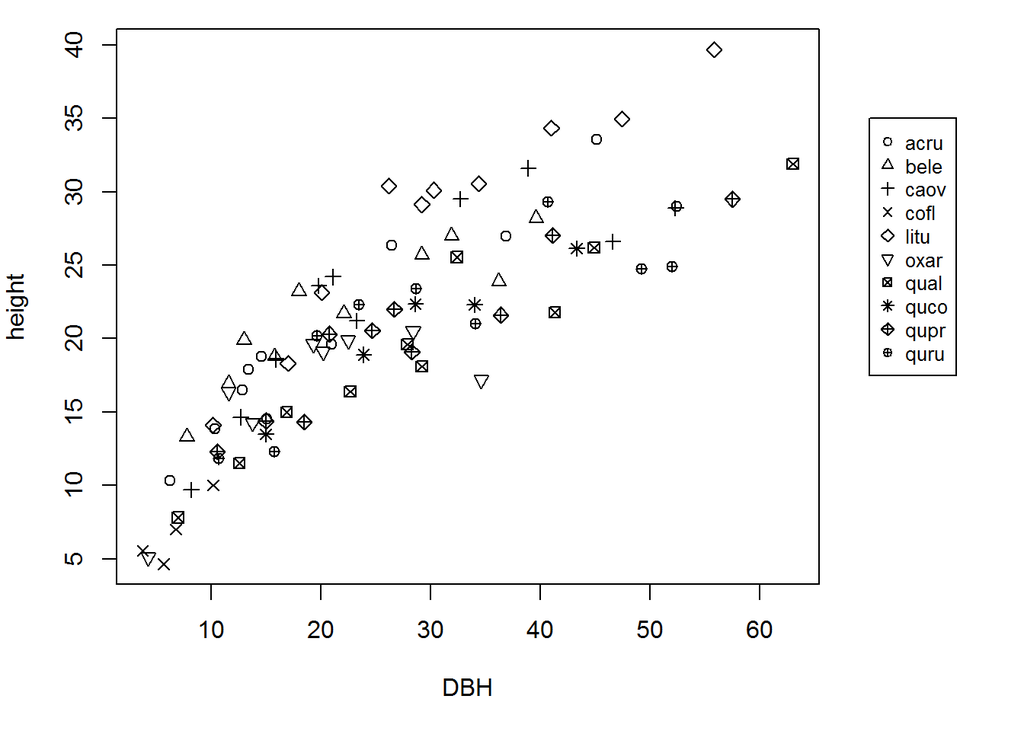

```r
# read in data and split data.frame by species
coweeta <- read.csv("coweeta.csv")

# set plot margins, with extra white space on right side
par(xpd = T, mar = c(5,4,1,7))
with(coweeta, plot(height ~ DBH, pch=c(1:10)[species]))
legend(70, 35, levels(coweeta$species), pch=1:10, cex=0.8)
```

# Multi-panel plots

There are multiple ways to set up a multi-panel plot, the simplest of which is to use the ‘mfrow’ (or ‘mfcol’) argument with the ‘par’ function.

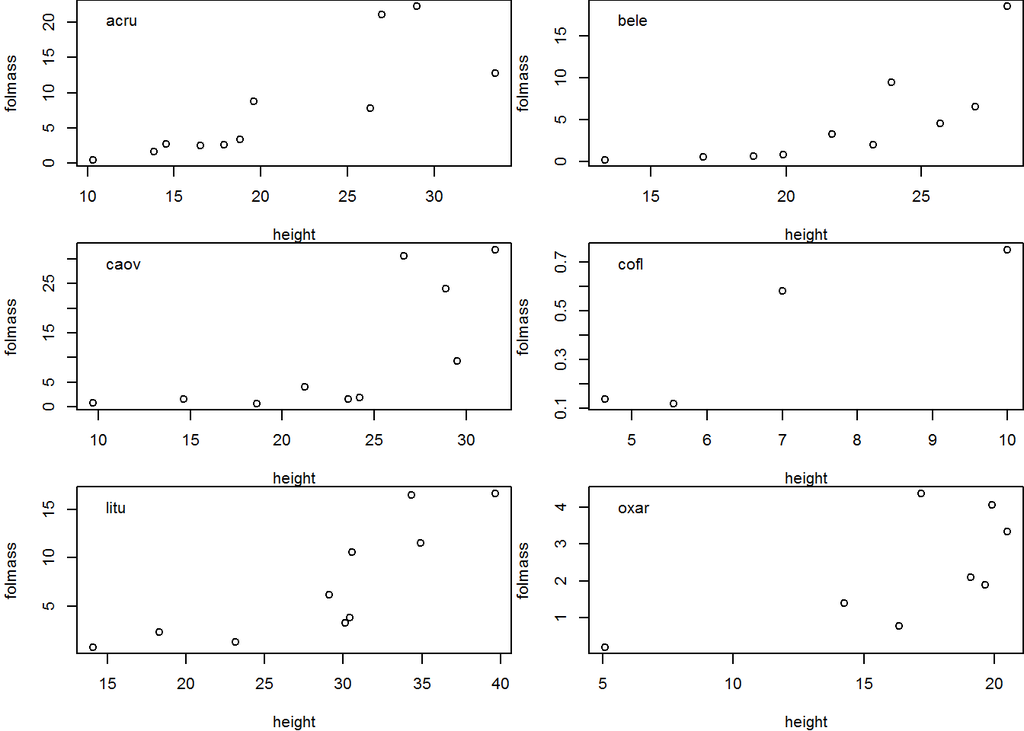

```r
# split data.frame by species
coweeta.spl <- split(coweeta, coweeta$species)

# set up graphics window with three rows and two columns
# also modify margins so plots are not compressed
par(mfrow=c(3,2), mar=c(4, 4, 0, 0))

# produce plot for each of the first six species
for(i in 1:6) {
  with(coweeta.spl[[i]], plot(folmass ~ height))
  legend('topleft', names(coweeta.spl)[i], bty='n')
}
```

**Try this yourself:** In the above example, use a different colour for each species. First set up a vector of colours, then index the vector in the plot statement.

For plots such as these, it would be nicer to only have consistent axes and one title on each of the x- and y-axes. We can do this by specifying the axis limits and suppressing the axis labels during the call to ‘plot’ and then using the ‘axis’ and ‘mtext’ functions to insert axes for each plot and text to the outer margins.

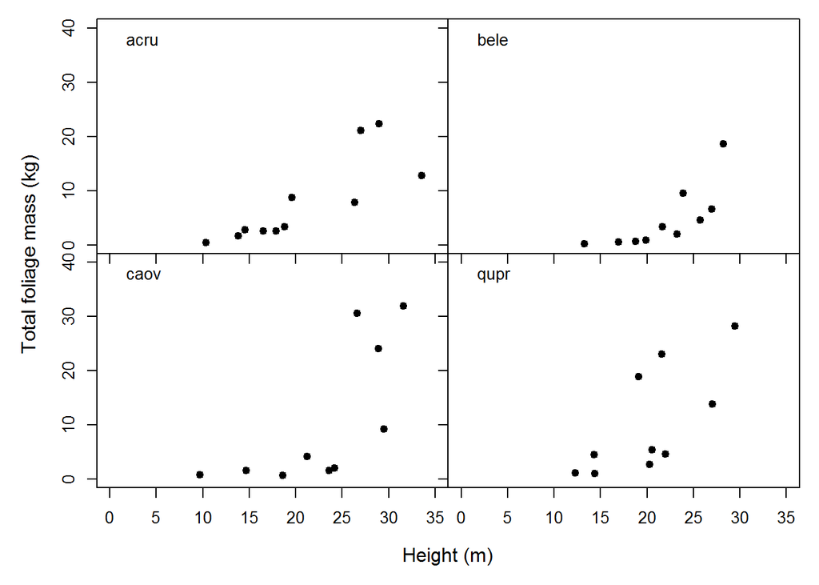

```r
# Make a plotting function that takes species as argument
plotfun <- function(spec){
  with(subset(coweeta, species == spec),
      plot(height, folmass, pch=19, axes=FALSE,
           xlim=c(0,35),
           ylim=c(0,40)))
  legend("topleft", spec, bty='n')
}

# set panel orientation, size of inner and outer margins
par(mfrow=c(2,2), mar=c(0,0,0,0), oma=c(5,5,1,1))

# panel 1, top left, labels on left but not bottom axis
plotfun("acru")
axis(1, labels=FALSE)
axis(2)
box()

# panel 2, top right, no labels
plotfun("bele")
axis(1, labels=FALSE)
axis(2, labels=FALSE)
box()

# panel 3, bottom left, labels on both axes
plotfun("caov")
axis(1)
axis(2)
box()

# panel 4, bottom right, label on bottom but not left axis
plotfun("qupr")
axis(1)
axis(2, labels=FALSE)
box()

# title for x-axis
mtext(side=1, line=3, outer=TRUE, text="Height (m)")
# title for y-axis
mtext(side=2, line=3, outer=TRUE, text="Total foliage mass (kg)")
```

Note that this can also be done easily using functions in the ‘ggplot2’ library.

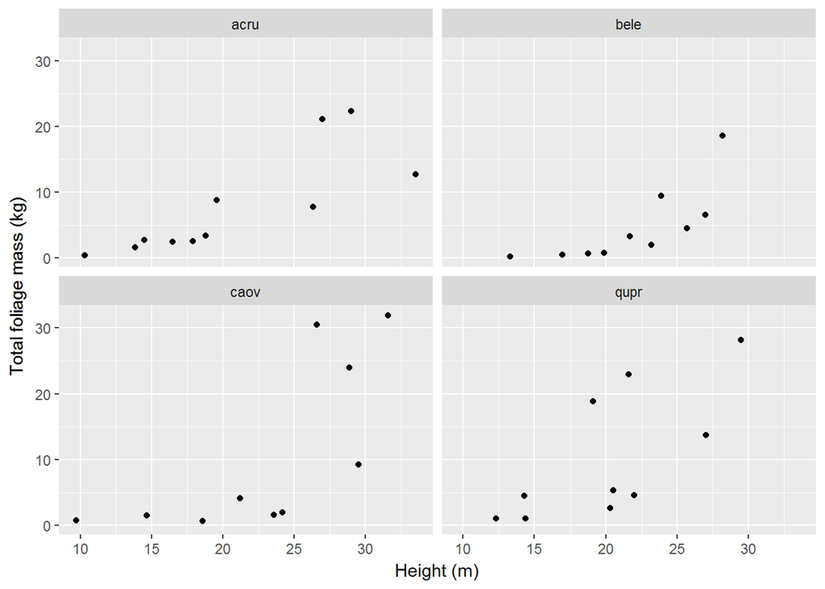

```r
library(ggplot2)
cowsub <- subset(coweeta, species %in% c("acru","bele","caov","qupr"))

ggplot(cowsub, aes(x=height, y=folmass)) +
  geom_point() +
  facet_wrap(~species, nrow=2) +
  labs(x="Height (m)", y="Total foliage mass (kg)")
```

## Using ‘layout’ for uneven layouts

We can define more complicated layouts using the ‘layout’ function. For example, lets look at an example with two rows of plots but with unequal numbers of plots on each row.

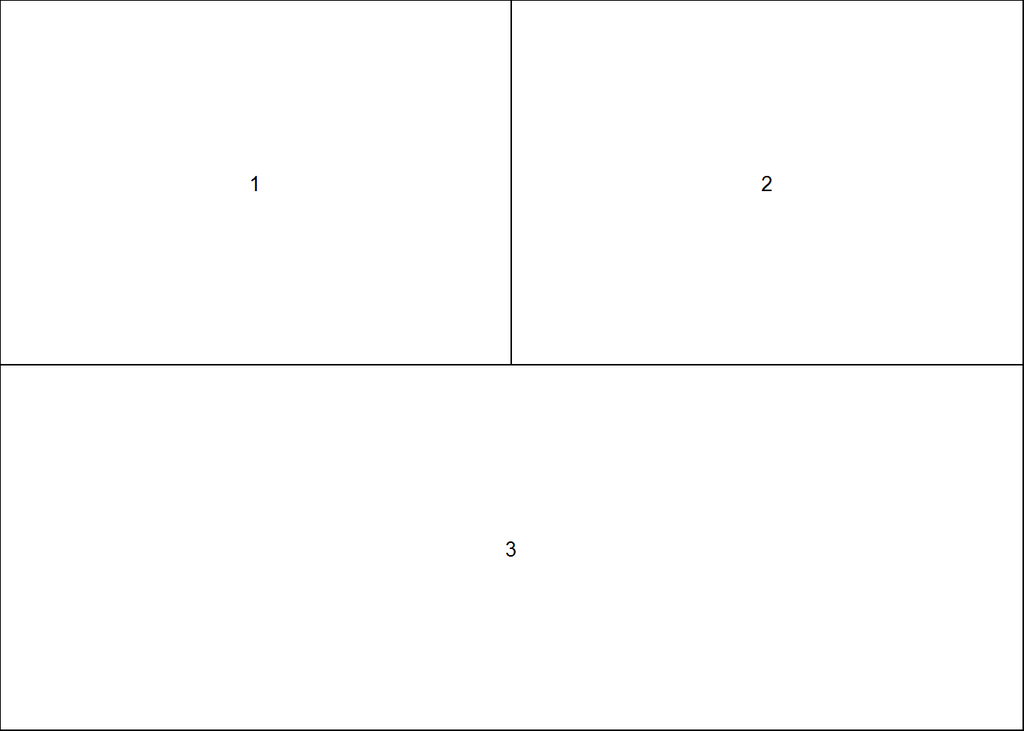

```r
# generate data subset
cowsub <- droplevels(subset(coweeta, species %in% c("acru","bele","caov","qupr")))

# specify layout using a matrix
# numbers in the matrix elements refer to plot numbers in that section
l <- layout(matrix(c(1, 2, 3, 3), nrow=2, byrow=T))

# show plot layout
layout.show(l)
```

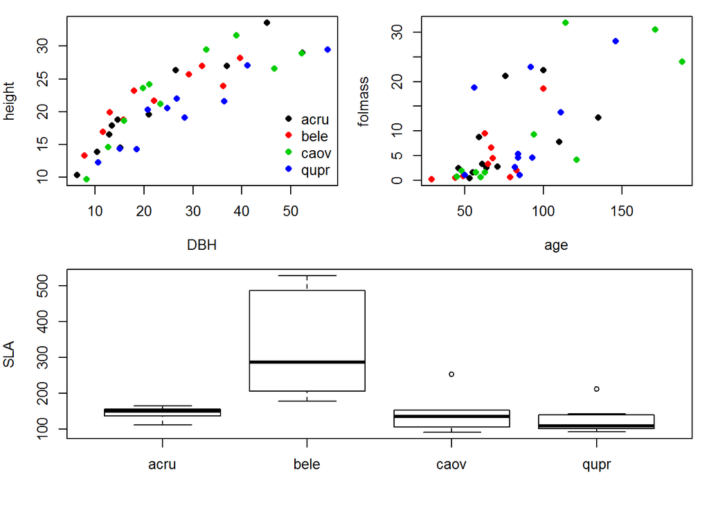

```r
# set margins
par(mar=c(4, 4, 1, 1))

# produce the three plots
# plot 1, top left, with legend
with(cowsub, plot(height ~ DBH, col=species, pch=16))
legend('bottomright', legend=levels(cowsub$species), pch=16, col=palette()[1:4], bty='n')
# plot 2, top right
with(cowsub, plot(folmass ~ age, col=species, pch=16))
# plot 3, along bottom
with(cowsub, boxplot(SLA ~ species, ylab='SLA'))
```

We can also specify different panel dimensions using the ‘widths’ and ‘heights’ arguments for the ‘layout’ function.

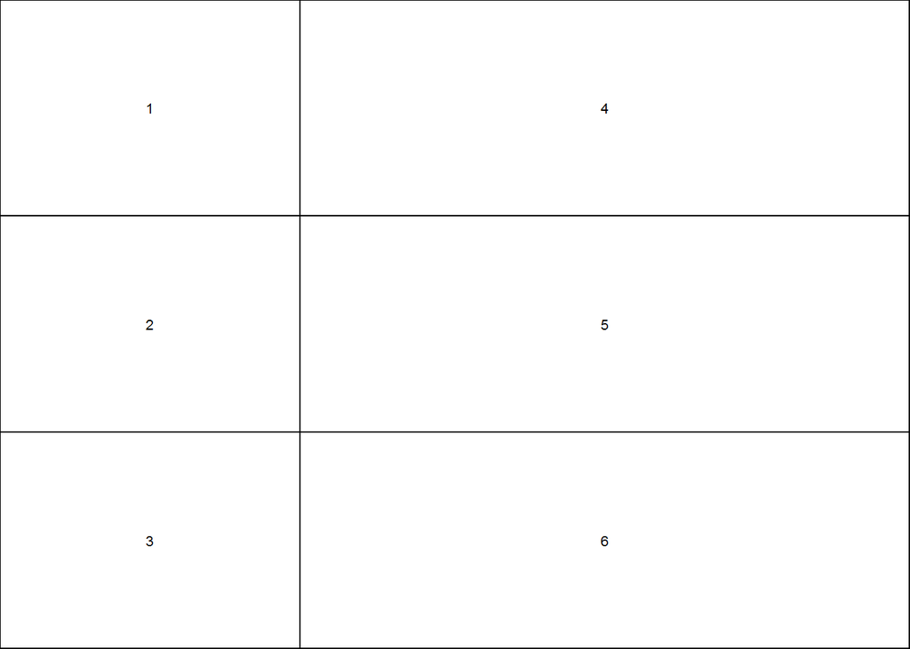

```r
# generate data subset
cowsub <- droplevels(subset(coweeta, species %in% c("acru","bele","caov","qupr")))

# specify layout using a matrix (note change to 'byrow=F')
# numbers in the matrix elements refer to plot numbers in that section
l <- layout(matrix(1:6, nrow=3, byrow=F), widths=c(0.33, 0.67), heights=c(rep(1/3, 3)))

# show plot layout
layout.show(l)
```

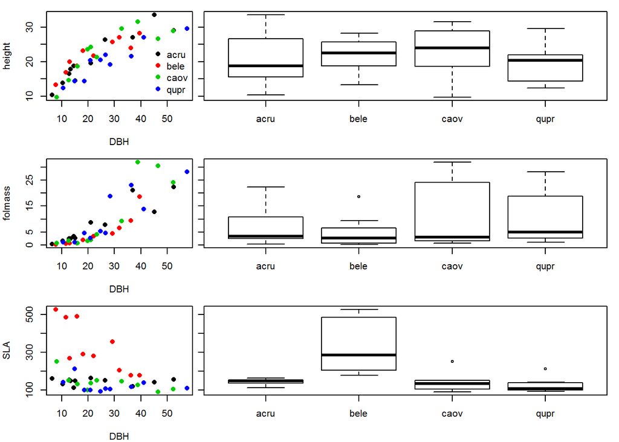

```r
# set margins
par(mar=c(4, 4, 1, 1))

# produce the plots
# three plots on left
with(cowsub, plot(height ~ DBH, col=species, pch=16))
legend('bottomright', legend=levels(cowsub$species), pch=16, col=palette()[1:4], bty='n')
with(cowsub, plot(folmass ~ DBH, col=species, pch=16))
with(cowsub, plot(SLA ~ DBH, col=species, pch=16))
# three plots on right (with reduced margins on left and no labels on y-axis)
par(mar=c(4, 0, 1, 1))
with(cowsub, boxplot(height ~ species, yaxt='n'))
axis(2, labels=F)
with(cowsub, boxplot(folmass ~ species, yaxt='n'))
axis(2, labels=F)
with(cowsub, boxplot(SLA ~ species, yaxt='n'))
axis(2, labels=F)
```

## Using ‘split.screen’ for complicated layouts

Some panel orientations are too difficult to set up using ‘layout’. In these cases, ‘split.screen’ can be very useful.

```r
# split display into two screens, one for each row
split.screen(c(2, 1))
```

```
## [1] 1 2
```

```r
# set margins
par(mar=c(4,4,1,1))

# split screen 1 further into three columns (screens 3, 4, and 5)
split.screen(c(1, 3), screen=1)
```

```
## [1] 3 4 5
```

```r
# screen 3, left
screen(3)
with(cowsub, plot(height ~ DBH, col=species, pch=16))
legend('bottomright', legend=levels(cowsub$species), pch=16, col=palette()[1:4], bty='n')
# screen 4, middle
screen(4)
with(cowsub, plot(folmass ~ DBH, col=species, pch=16))
# screen 5, right
screen(5)
with(cowsub, plot(SLA ~ DBH, col=species, pch=16))

# split screen 2 further into two colums (screens 6 and 7)
split.screen(c(1, 2), screen=2)
```

```
## [1] 6 7
```

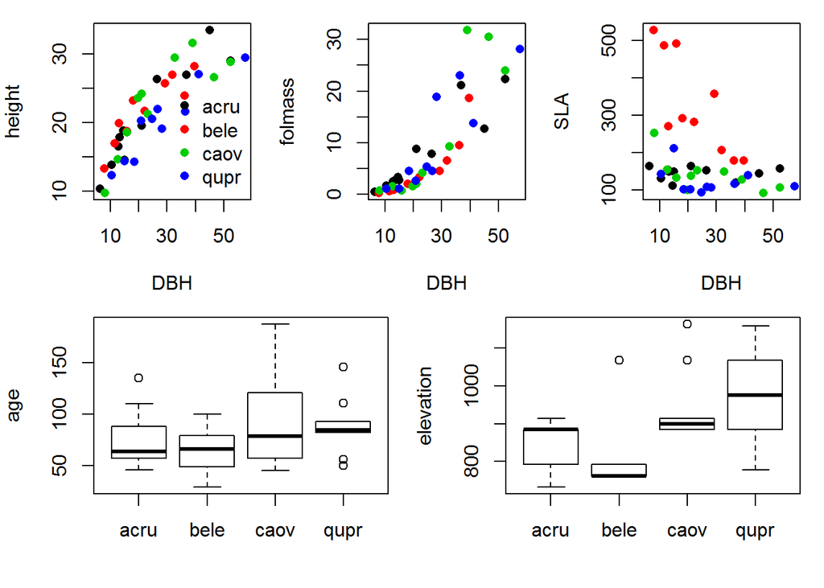

```r
# screen 6, left
screen(6)
with(cowsub, boxplot(age ~ species, ylab='age'))
# screen 7, right
screen(7)
with(cowsub, boxplot(elev ~ species, ylab='elevation'))
```

```r
# exit split-screen mode
close.screen(all=T)
```

# Adding images to a plot

We can insert these graphics directly into the plot after reading the image using functions from an appropriate library (e.g., ‘jpeg’, ‘tiff’, ‘png’) and rendering the image on top of the plot that we have produced. For example, when visualising the distribution of spore pigmentation among fungal species, it would be helpful to also include images that represent extreme values. Here we use the ‘rasterImage’ function from the ‘graphics’ library, which is loaded when starting R. (Note that it can be tricky to set the image size correctly so that the image isn’t distorted).

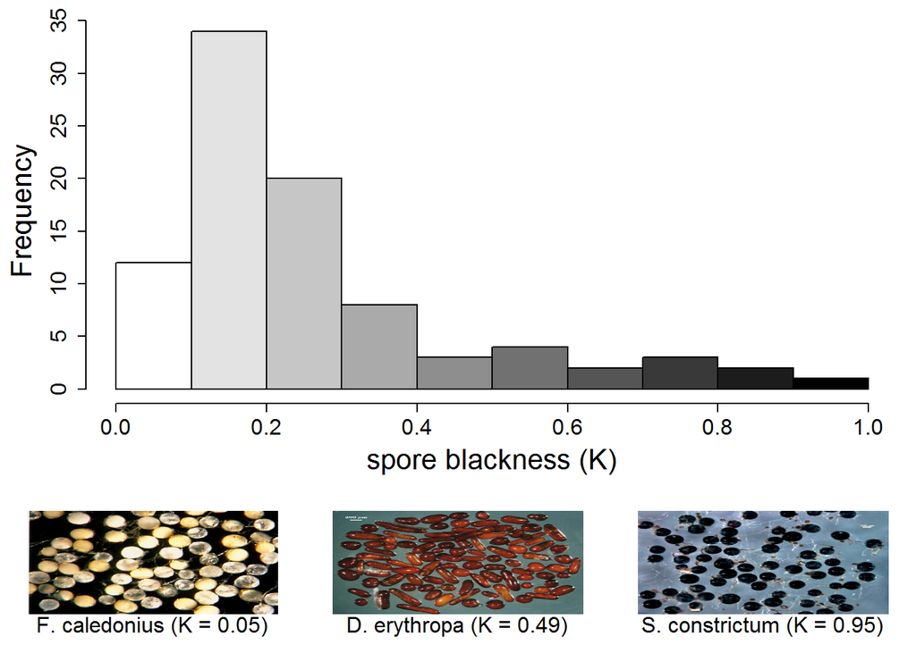

```r
# load library
library(jpeg)

# read in spore colour data
spores <- read.csv('sporecolour.csv')

# calculate spore 'blackness' for each row
spores$K <- 1 - apply(spores[, c('red', 'green', 'blue')], 1, max)/255

# read in three images representing three levels of blackness
caledonius <- readJPEG('Funneliformis_caledonius_immature.jpg')
erythropa <- readJPEG('Dentiscutata_erythropa_1.jpg')
constrictum <- readJPEG('Septoglomus_constrictum_1.jpg')

# set plot layout
layout(matrix(c(rep(1, 9), 2, 3, 4), nrow=4, byrow=T))

# plot histogram of spore 'blackness'
par(mar=c(5, 5, 1, 1))
hist(spores$K, main='', xlab='spore blackness (K)', cex.axis=1.5, cex.lab=2,
     breaks=10, col=grey(seq(from=1, to=0, length.out=10)))

# plot and raster images in bottom panels
# set margins
par(mar=c(2, 1, 1, 1))

# plot and raster image on left
plot(c(0, 1), c(0, 1), type='n', axes=F, xlab='', ylab='')
axis(1, at=0.5, labels='F. caledonius (K = 0.05)', tick=F, line=-1, cex.axis=1.5)
rasterImage(caledonius, 0, 0, 1, 1)  # modify image size by specifying different coordinates

# plot and raster middle image
plot(c(0, 1), c(0, 1), type='n', axes=F, xlab='', ylab='')
axis(1, at=0.5, labels='D. erythropa (K = 0.49)', tick=F, line=-1, cex.axis=1.5)
rasterImage(erythropa, 0, 0, 1, 1)  # modify image size by specifying different coordinates

#plot and raster image on right
plot(c(0, 1), c(0, 1), type='n', axes=F, xlab='', ylab='')
axis(1, at=0.5, labels='S. constrictum (K = 0.95)', tick=F, line=-1, cex.axis=1.5)
rasterImage(constrictum, 0, 0, 1, 1)  # modify image size by specifying different coordinates
```

## Interacting with graphics

It is possible to use the graphics window in an interactive way to obtain information contained within the plot. For instance, we have seen how we can import images into the graphics window, and we can also use the ‘locator’ function to identify points on those images and calculate their values.

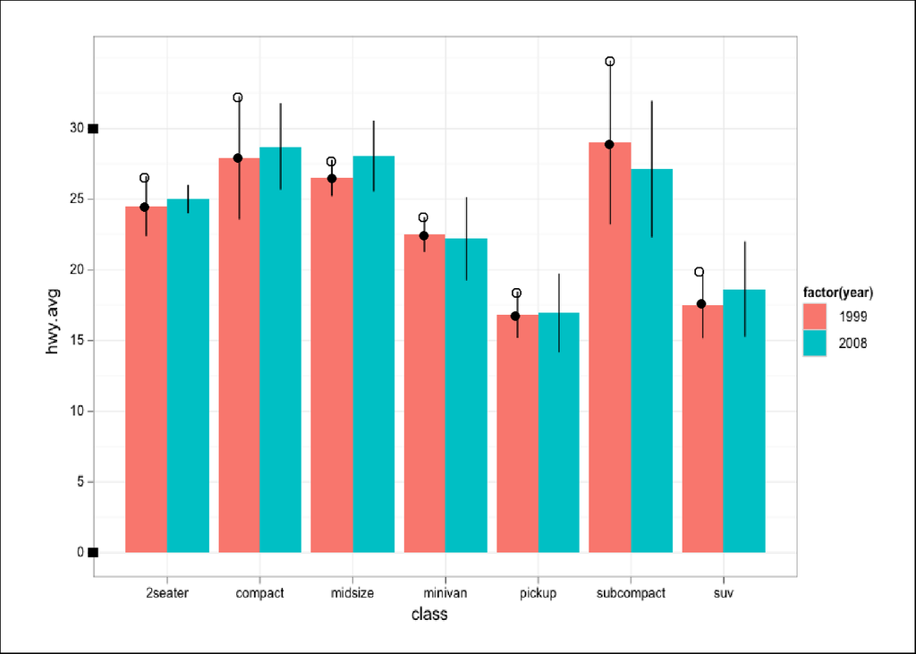

```r
# load library for reading 'png' image
library(png)

# load image data, prepare plot window and render in graphics window
# load image data
image <- readPNG('barplot1.png')
# set margins to zero on all sides
par(mar=rep(0, 4))
# new plot with x- and y-axis limits equalling width and height of image
plot(c(0, dim(image)[1]), c(0, dim(image)[2]), type='n')
# render image within plot
rasterImage(image, 0, 0, dim(image)[1], dim(image)[2], interpolate=F)

# locate mean values for 1999
means.1999 <- locator(7)

# locate upper CI for 1999
cis.1999 <- locator(7)

# locate range of y-axis
y0 <- locator(1)
y30 <- locator(1)

# show points that were clicked on
points(means.1999, pch=16)
points(cis.1999, pch=1)
points(y0, pch=15)
points(y30, pch=15)
```

```r
# calculate actual means
30 * (means.1999$y - y0$y) / (y30$y - y0$y)
```

```
## [1] 24.45166 27.93661 26.49128 22.40729 16.75911 28.89699 17.60063
```

```r
# calculate actual CIs
30 * (cis.1999$y - means.1999$y) / (y30$y - y0$y)
```

```
## [1] 2.087163 4.288431 1.198098 1.326466 1.621236 5.881141 2.263074
```

# Plots with too many points

When making a scatter plot of a large dataset, a common problem is that many points are plotted on top of each other. This is sometimes referred to as ‘overplotting’. This is an issue because we no longer can see where most of the data occur, and visually this problem tends to make us think the variation in the data is larger than it actually is.

For this problem we use 18k observations of air temperature and air pressure measured at the HFE experiment on the Hawkesbury campus in 2008.

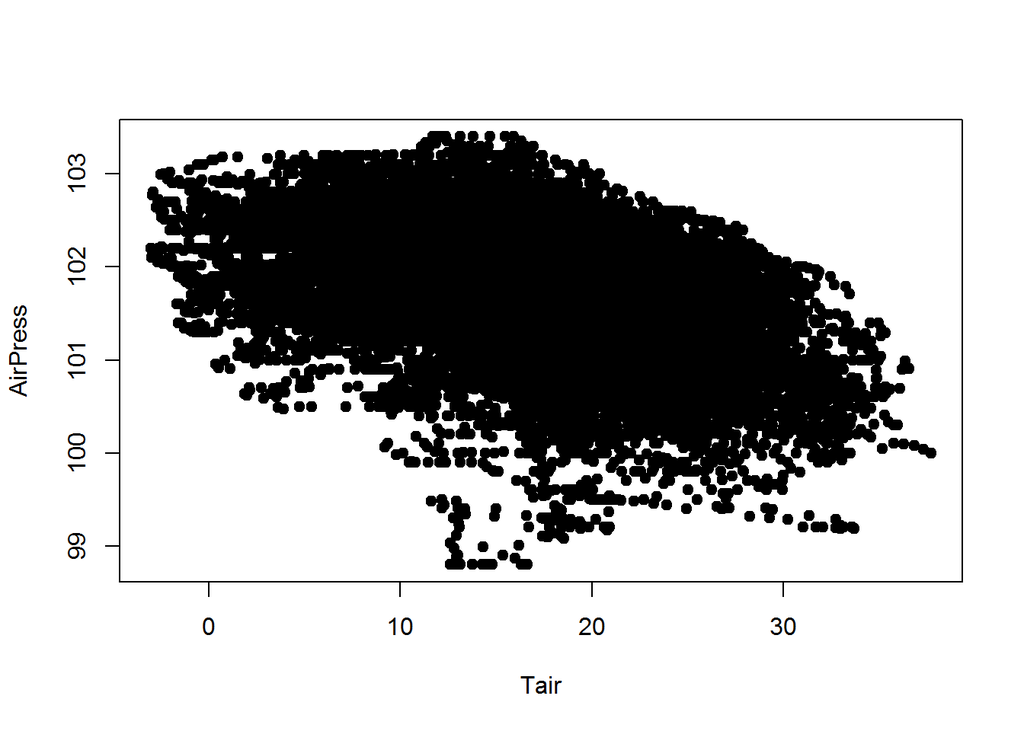

```r
hfemet <- read.csv("HFEmet2008.csv")
hfemet <- subset(hfemet, AirPress > 98) # remove a couple of outliers

# Using a filled symbol makes the problem a bit worse, of course.
with(hfemet, plot(Tair, AirPress, pch=19))
```

It is impossible to see whether some values are more common than others, we just see a black circle (except for the edges).

The first approach, which is only partially successful, is to use transparent symbols. To some extent, the colour will be a function of how many points are overplotted. Unfortunately this approach is quite limited for larger datasets (but for smaller datasets with minor overplotting issues, it can be very effective to use transparent colours).

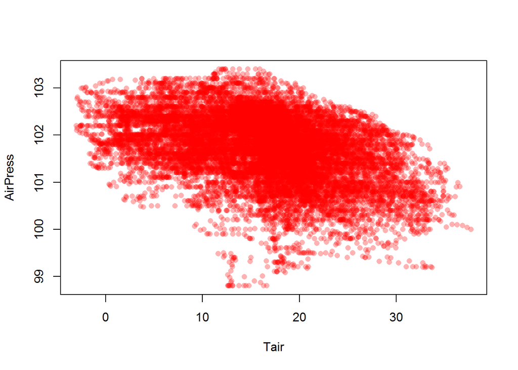

```r
# for 'alpha'
library(scales)
with(hfemet, plot(Tair, AirPress, pch=16, col=alpha("red",0.3)))
```

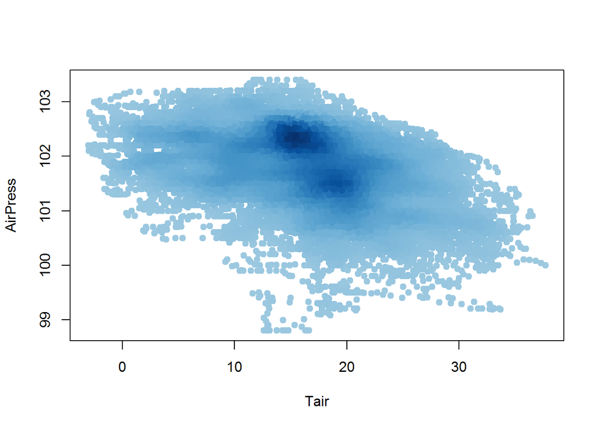

```r
# Setup vector of colours - based on a local density estimator.
cols <- with(hfemet, densCols(Tair, AirPress))

# Use the vectour of colours in a standard scatter plot.
with(hfemet, plot(Tair, AirPress, col=cols, pch=19))
```

The next approach is to use a ‘hexbin’ plot, which divides the plotting region into hexagonals, and counts the number of observations in each. The **disadvantage** of hexbin is that the `grid` graphics system is used, which is not compatible with base or ggplot. Thus it is difficult to adjust anything on the figure, and not possible to use it in conjunction with `par`, or `layout`, or basically anything you know.

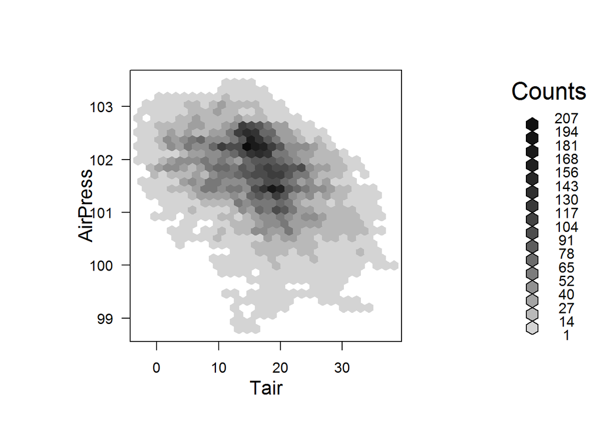

```r
library(hexbin)
h <- with(hfemet, hexbin(Tair, AirPress))
plot(h)
```

Finally, ggplot also has a hexbin built in, which we can invoke with `stat_binhex`, like so. Note the use of `scale_fill_gradientn` to set the colours (the default is not great).

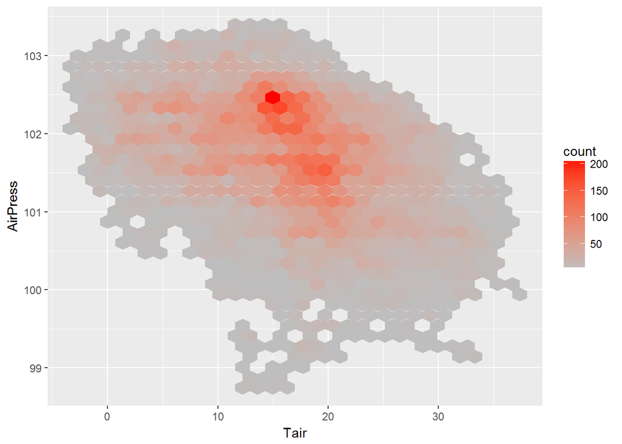

```r
ggplot(hfemet, aes(Tair, AirPress)) + stat_binhex() +
  scale_fill_gradientn(colours=c("grey","red"))
```

# Line plots

It is straightforward in base R to make a scatter plot where points are colours by levels of a factor variable. It is however far from easy to do the same in a line plot, where points for a group are connected by a line. The solution in base R is to write somewhat verbose code, using a for loop, and adding one line at a time for each group.

The following example uses election poll data for a Dutch election in 2012. Note that the data are in **wide format**; poll percentages for each party are organized in different columns.

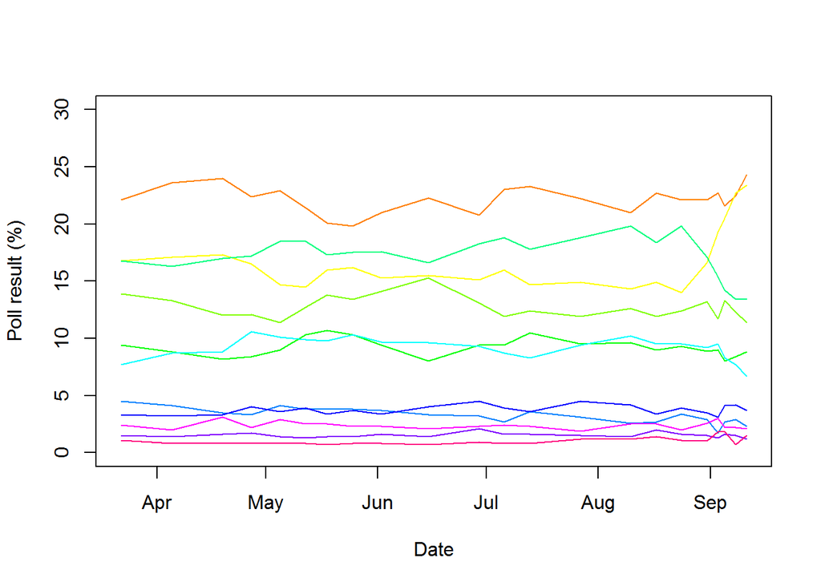

```r
# Read the Dutch election poll data
election <- read.csv("dutchelection.csv")
election$Date <- as.Date(election$Date)

# Plot the first variable (make sure to set the Y axis range
# wide enough for all the other data!)
plot(VVD ~ Date, data=election, type='l', col="blue", ylim=c(0,30),
     ylab="Poll result (%)")

palette(rainbow(12))

# Loop through columns
for(i in 2:ncol(election)){
  # Find column name
  party <- names(election)[i]

  # Use column name to index data, and add a line
  lines(election$Date, election[,party], col=palette()[i])
}
```

For line plots, `ggplot2` is much easier to use - but we do have to reshape the data to *long format*, since `ggplot` does not do anything with wide format. In this case we can conveniently use `melt` from `reshape2`. Another major benefit is that ggplot adds a legend by default.

We also show how to set the colours of the line, to make it look more like the plot with base, and also to use a more simple theme, and switch off the grid lines.

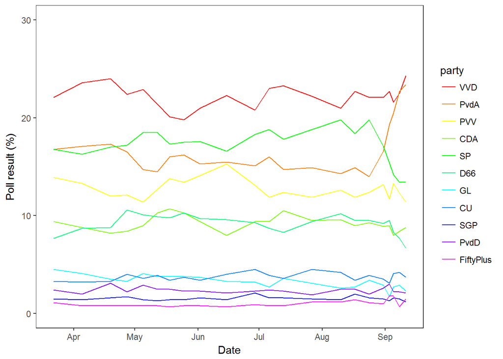

```r
library(reshape2)

# Make data into long format
elect_long <- melt(election, id.vars="Date",
                   variable.name="party",
                   value.name="vote_percent")

# Setting col=party in the aes statement will make a line for each party,
# with a different colour
ggplot(elect_long, aes(Date, vote_percent, col=party)) +
  geom_path() + scale_colour_manual(values=rainbow(12)) +
  ylim(c(0,30)) +
  labs(x="Date", y="Poll result (%)") +
  theme_bw() +  # Black and white theme
  theme(panel.grid.major = element_blank(), panel.grid.minor = element_blank()) # No grid lines
```

# Grouped and stacked bar plots

## Tabulated data

In this example, we make grouped and stacked bar plots for data that are already tabulated. The example comes from Berkeley admissions data into the graduate school for 1973, where student numbers have already been tabulated, and separated into ‘admitted’, ‘denied’, for male and female students. The data as provided is already in *wide format*, in which case it is very convenient to use `barplot` directly to construct a stacked or grouped barplot.

```r
berk <- read.csv("berkeley.csv")
berk
```

```
##   Department Admitted_Male Denied_Male Admitted_Female Denied_Female
## 1          A           512         313              89            19
## 2          B           313         207              17             8
## 3          C           120         205             202           391
## 4          D           138         279             131           244
## 5          E            53         138              94           299
## 6          F            22         351              24           317
```

To make a stacked barplot, we first have to prepare a `matrix` with the data (a dataframe won’t do). Each column will be a bar, or group of bars, with each group defined by the rows. In this case, we want `Admitted_Female` and `Denied_Female` to be stacked.

```r
m <- t(as.matrix(berk[,c("Admitted_Female","Denied_Female")]))
m
```

```
##                 [,1] [,2] [,3] [,4] [,5] [,6]
## Admitted_Female   89   17  202  131   94   24
## Denied_Female     19    8  391  244  299  317
```

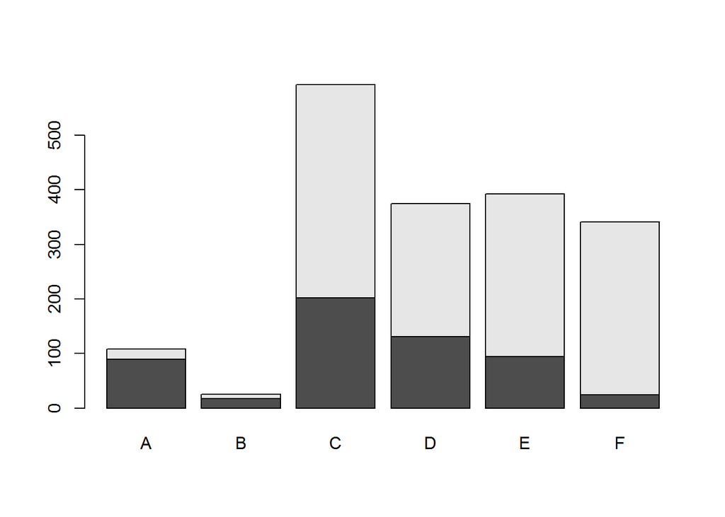

```r
# Plot matrix - makes a stacked barplot. We provide the names for the bars via `names.arg`
barplot(m, names.arg=berk$Department)
```

**Try this yourself** : You can make a grouped barplot by specifying `beside=TRUE` in the call to barplot.

The `gplots` package provides the `barplot2` function which adds useful functionality like automatic legend placement, and somewhat nicer default colours (though not for just two groups as in this example).

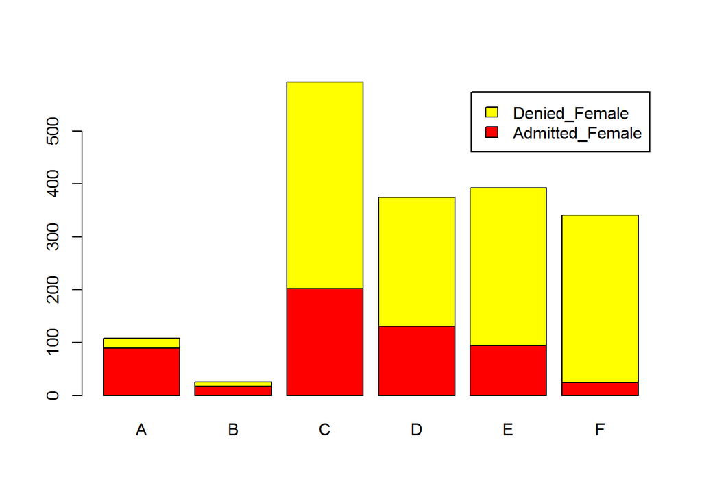

```r
library(gplots)
barplot2(m, names.arg=berk$Department, legend=TRUE)
```

The following example shows how to use `ggplot2` to make the same (well, similar) figure. The difficulty here is that `ggplot2` can **only data in long format**. Normally this is not a problem, but in this case it makes life difficult and we have to use `reshape` to make the data in long format. Also note the use of the “pipe operator” `%>%` to make a pipeline. The way this works is that the output from the first statement (`reshape`) is sent to the next statement (`rename`), where it is used as the *first argument*, and so on. This makes code shorter and often easier to read.

```r
# for %>%, filter
library(dplyr)

# First make the dataframe into long format.
# The column names are now levels of a new factor variable (called 'variable' by default)
berklong <- melt(berk, id.vars="Department",
                 value.name="Nr_students")

# The next and final step is to separate the 'variable' into
# gender and status (admitted/denied)
library(tidyr)
berklong <- separate(berklong, "variable", c("status","gender"))
head(berklong)
```

```
##   Department   status gender Nr_students
## 1          A Admitted   Male         512
## 2          B Admitted   Male         313
## 3          C Admitted   Male         120
## 4          D Admitted   Male         138
## 5          E Admitted   Male          53
## 6          F Admitted   Male          22
```

Now we are ready to make the plot similar to the one above. In `geom_bar`, the argument `stat="identity"` indicates that the *actual data* in the dataframe will be used to draw the bars. This is needed because it is also possible to first tabulate (or otherwise summarize) the data in the call to `geom_bar` before plotting (see next Section).

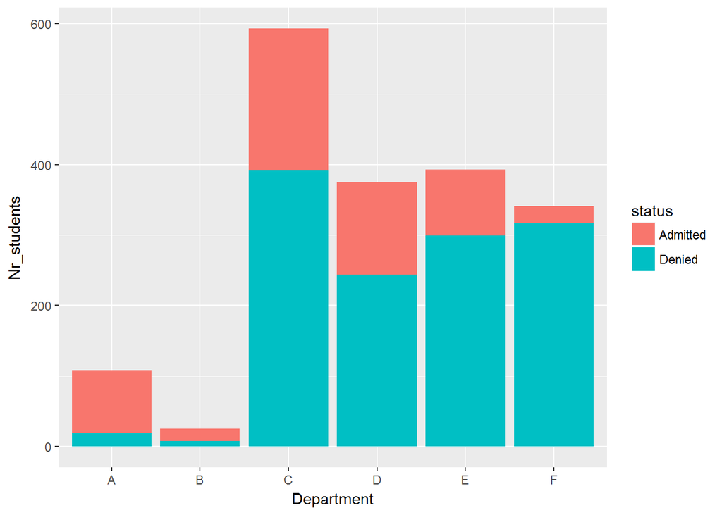

```r
# Take subset with only Female students (using filter from dplyr - can use subset here as well)
filter(berklong, gender == "Female") %>%
ggplot(aes(x=Department, y=Nr_students, fill=status)) +
  geom_bar(stat="identity")
```

Once we have the data in the right format, it is also straightforward to make a multiple panel graph, split by `gender`, using `facet_wrap`.

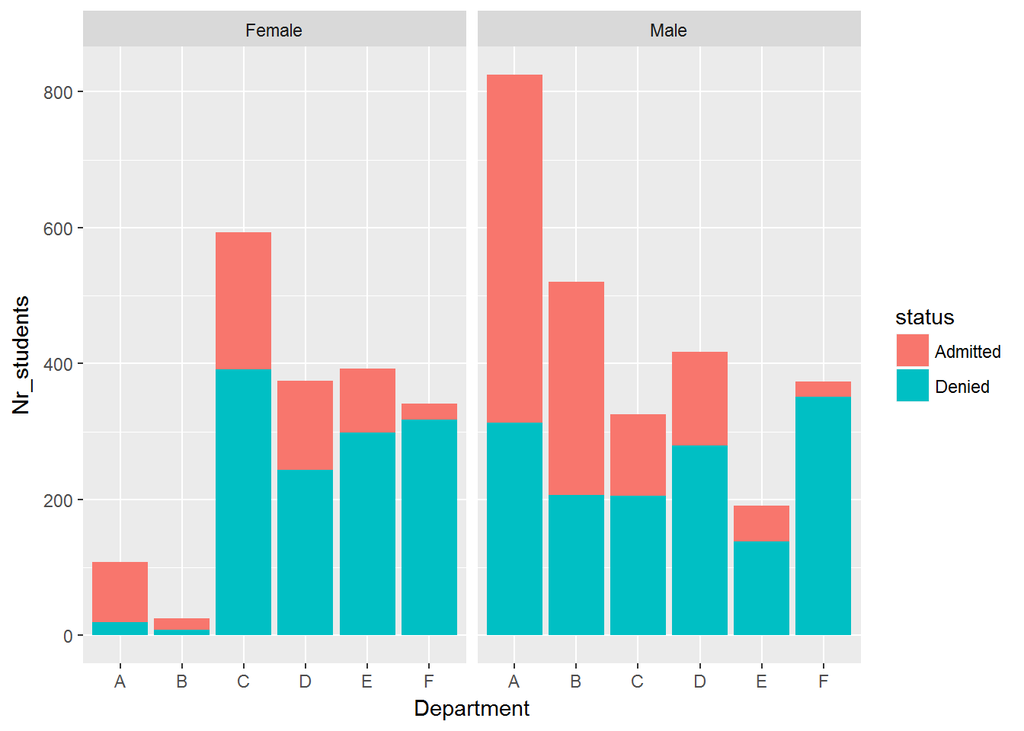

```r
ggplot(berklong, aes(x=Department, y=Nr_students, fill=status)) +
  geom_bar(stat="identity") + facet_wrap(~gender)
```

**Try this yourself** : the order of the ‘stacking’ in the barplots is determined by the order of the levels of the factor variable used to colour the sections of the bar. Try reversing it with `berklong$status <- factor(berklong$status, levels=c("Denied","Admitted"))`

In the plots above, the default barplot is to stack the individual groups. Two options are useful as well, the first is to place each of the groups next to each other using `position=position_dodge()`. In this example we also change the colours of the groups with `scale_fill_manual`.

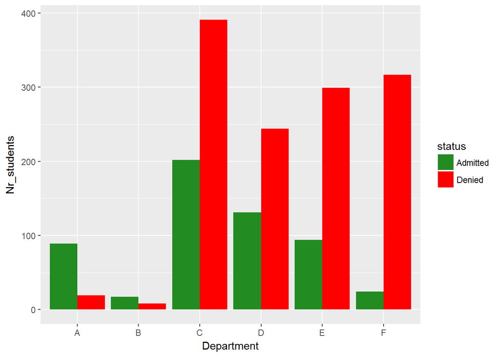

```r
filter(berklong, gender == "Female") %>%
ggplot(aes(x=Department, y=Nr_students, fill=status)) +
  geom_bar(stat="identity", position=position_dodge()) +
  scale_fill_manual(values=c("forestgreen","red"))
```

And finally, for data like these, it is also useful to plot the admitted / denied data as percentages, by using `position=position_fill()`, and the use of the `scales` package to add percent labels on the y-axis.

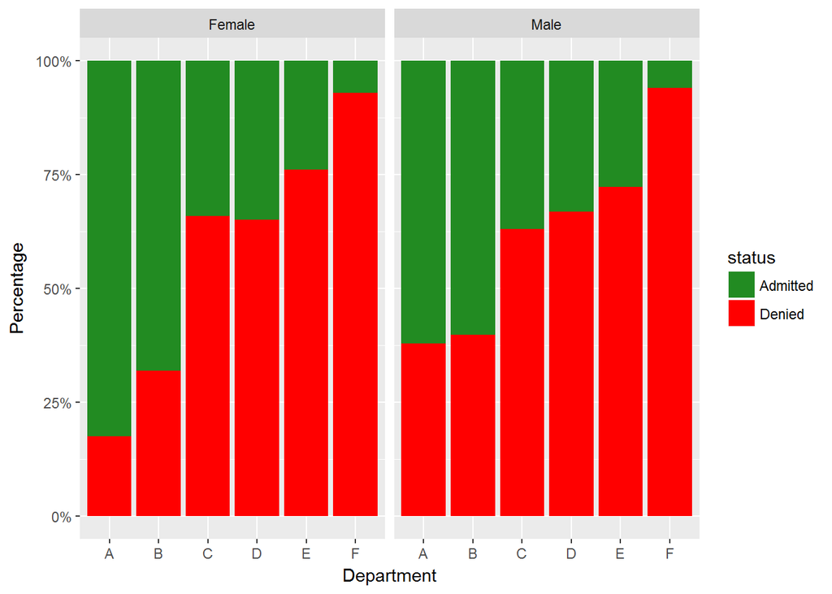

```r
library(scales) # for percent()
ggplot(berklong, aes(x=Department, y=Nr_students, fill=status)) +
  geom_bar(stat="identity", position=position_fill()) +
  scale_fill_manual(values=c("forestgreen","red")) +
  labs(y="Percentage") +
  facet_wrap(~gender) +
  scale_y_continuous(labels = percent)
```

## Untabulated data

This example shows how to make bar plots of frequencies (counts) of data by groups, using base or ggplot2.

For base, we can use `table` to produce a table of counts, or `tapply` to calculate a simple statistic by a combination of factor variables.. Since `table` and `tapply` both return a matrix by default, it is very convenient to use them in `barplot` to make a grouped barplot.

We here use the famous Titanic dataset, and sum the number of survivors and non-survivors by passenger class and sex.

```r
titanic <- read.table("titanic.txt", header=TRUE)
head(titanic)
```

```
##                                            Name PClass   Age    Sex
## 1                  Allen, Miss Elisabeth Walton    1st 29.00 female
## 2                   Allison, Miss Helen Loraine    1st  2.00 female
## 3           Allison, Mr Hudson Joshua Creighton    1st 30.00   male
## 4 Allison, Mrs Hudson JC (Bessie Waldo Daniels)    1st 25.00 female
## 5                 Allison, Master Hudson Trevor    1st  0.92   male
## 6                            Anderson, Mr Harry    1st 47.00   male
##   Survived
## 1        1
## 2        0
## 3        0
## 4        0
## 5        1
## 6        1
```

Make table of sums of survived (`Survived = 1`) or perished (`Survived = 0`) by passenger class and sex.

```r
titan_surv <- with(titanic, tapply(Survived, list(PClass, Sex), FUN=sum))
```

The number of survivors is not that interesting if we don’t know how many passengers were in each group. We can tabulate that with `table` :

```r
titan_n <- with(titanic, table(PClass, Sex))
```

Now we can calculate the *proportion* survived by simply dividing `titan_surv` by `titan_n` - this works because both matrices are the same dimension (check this!).

```r
titan_surv_prop <- titan_surv / titan_n
```

And we can use this to make our barplot (again using `barplot2` from the `gplots` package). This time a stacked barplot makes no sense - we want the bars within a group to be next to each other.

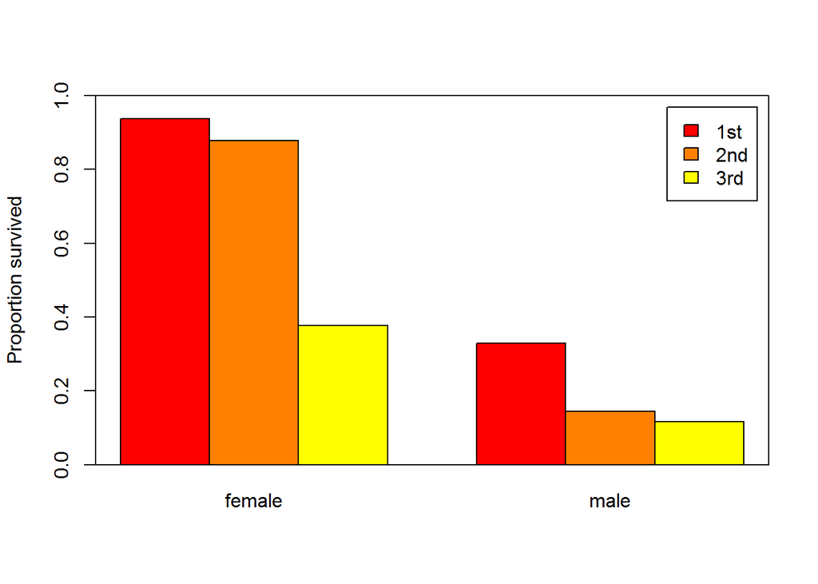

```r
barplot2(titan_surv_prop, beside=TRUE, legend=TRUE, ylab="Proportion survived", ylim=c(0,1))
box()
```

We can make the same plot using `ggplot`, as follows. To calculate the proportion survived, we use the `dplyr` package. First, set the grouping variables (PClass and Sex), and then summarize the data by these groupings to yield a table similar to the one above (but in long format). This can then be sent to `ggplot`.

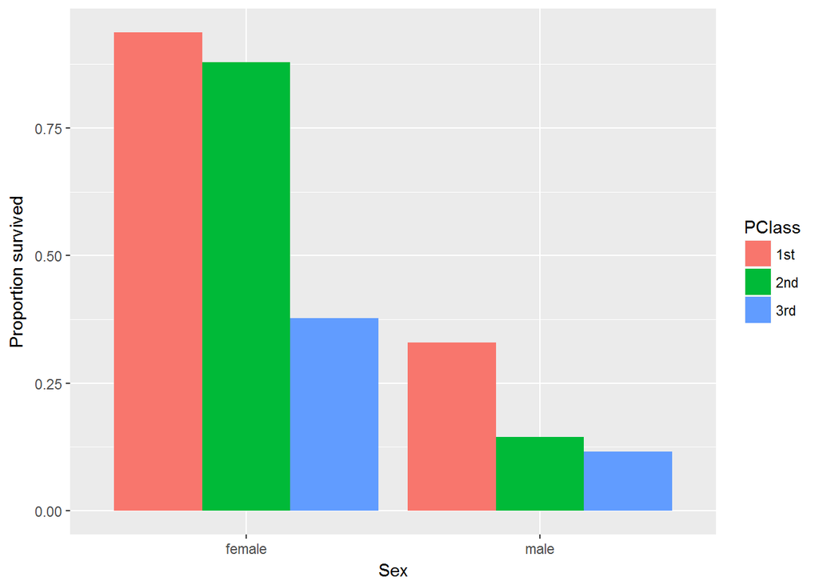

```r
library(dplyr)
surv_prop_2 <- group_by(titanic, PClass, Sex) %>%
  summarize(surv_prop = sum(Survived) / n())
# the n() function comes with dplyr; a simple count function.

# Make plot
# Note use of 'position="dodge"' to place bars next to each other.
# Try switching Sex and PClass to see what happens to the plot.
ggplot(surv_prop_2, aes(Sex, surv_prop, fill=PClass )) +
  geom_bar(stat="identity", position="dodge") +
  labs(y = "Proportion survived")
```

# Customizing Date-Time axes

This example shows how to customize plotting of timeseries, specifically a numeric vector against a vector of class `Date` or `POSIXct` (i.e. a date-time representation). For the `POSIXct` example, we will use the “hfemet2008.csv” dataset used in an example above, and first prepare the data.

```r
hfemet <- read.csv("HFEmet2008.csv")

# Convert DateTime to POSIXct using lubridate
library(lubridate)
hfemet$DateTime <- mdy_hm(hfemet$DateTime)
```

Now plot the data. To customize the x-axis, use `axes=FALSE` to suppress the axes, and then add them in a customized way using `axis.POSIXct`. Date formatting strings can be found on `?strptime`.

**Try this yourself:** First make the below plot with the default axes, to note that the labels on the X-axis are not placed for every month, but rather every two months (and ending in January though the data actually end in December).

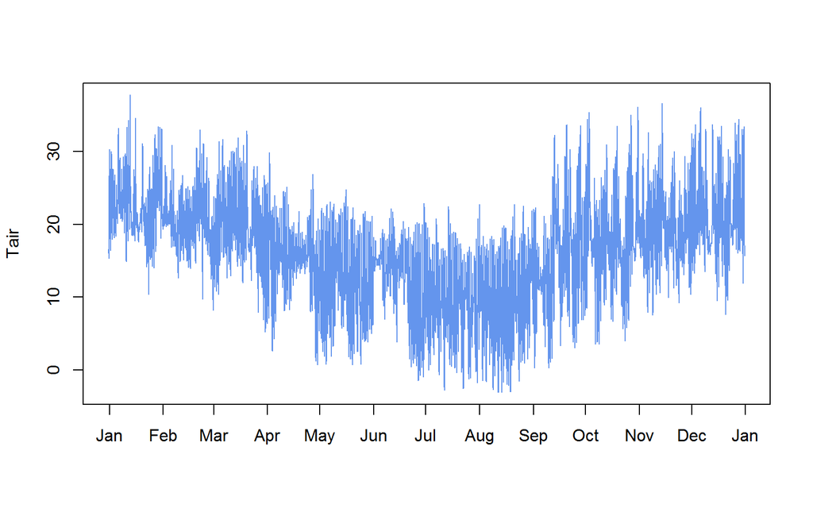

```r
with(hfemet, plot(DateTime, Tair, type='l', col="cornflowerblue", axes=FALSE, xlab=""))
axis(2) # y-axis

# Make vector of Date-times where you want tick marks to be placed:
d_maj <- seq(from=ymd_hm("2008-1-1 12:00"), to=ymd_hm("2009-1-31 12:00"), by="1 month")

axis.POSIXct(1, at=d_maj, format="%b")
box()
```

```r
# Or, use month numbers:
#axis.POSIXct(1, at=d_maj, format="%m")

# Or, use month/year:
# axis.POSIXct(1, at=d_maj, format="%m/%y")
```

**Try this yourself:** Make an x-axis where the Date labels are placed every three months (`by="3 months"` in the `seq` statement), but tick marks are placed every month. To do this, use `axis.POSIXct` twice: once for the axis with labels (every 3 months), and once wihtout labels by setting `labels=FALSE`.

Similarly, we can customize the axis when plotting just a single day. Here the axis labels are set very small to avoid labels being chopped off.

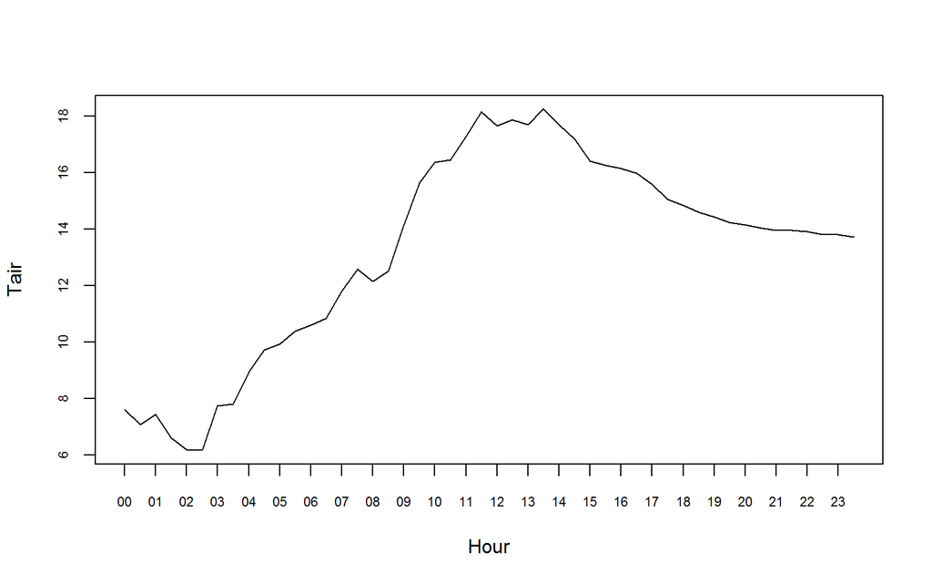

```r
par(cex.axis=0.7)
hfemet_jun1 <- subset(hfemet, as.Date(DateTime) == "2008-6-1")

with(hfemet_jun1, plot(DateTime, Tair, type='l',
                       xlab="Hour",
                       axes=FALSE))
d <- with(hfemet_jun1, seq(min(DateTime), max(DateTime), by="1 hour"))
axis.POSIXct(1, at=d, format="%H")
axis(2)
box()
```

Alternatively, we can use a tick mark for every hour, but only place labels every 3 hours. In addition, we make the tick marks for non-label ticksa bit shorter, by setting the `tcl` parameter (which is sent to `par` via `axis.POSIXct`).

Also note we extend the x-axis range a bit by adding `30*60` to the `max(DateTime)`, which is 30 min since DateTime (`POSIXct`) is coded as number of seconds (since some baseline date).

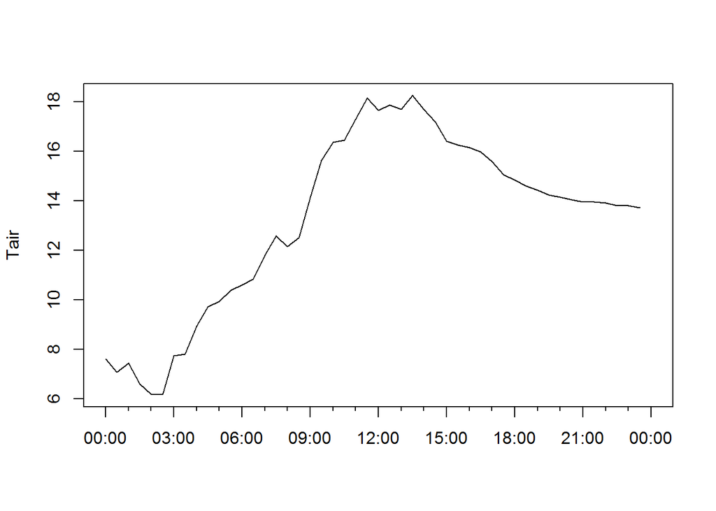

```r
with(hfemet_jun1, plot(DateTime, Tair, type='l',
                       xlab="",
                       xlim=c(min(DateTime), max(DateTime)+30*60),
                       axes=FALSE))
axis.POSIXct(1, at=d, format="%H", labels=FALSE, tcl=-0.2)

lab <- with(hfemet_jun1, seq(min(DateTime), max(DateTime)+30*60, by="3 hours"))
axis.POSIXct(1, at=lab, format="%H:%M", labels=TRUE)
axis(2)
box()
```